# terra-indigena-estrada

Darren Norris

2022-12-02

# 1 Apresentação

O objetivo é calcular métricas de paisagem, descrever a composição e a configuração da paisagem e avaliar o papel da Terra Indígena Uaçá ao redor da rodovia BR-156.

As métricas da paisagem nos ajudam a entender as mudanças na paisagem de diferentes perspectivas (visual, ecológica, cultural). Asssim sendo, análises com métricas de paisagem é um atividade fundamental na ecologia da paisagem. Nesta exemplo (https://rpubs.com/doon75/terra-indigena-estrada) aprenderemos sobre como analisar a cobertura da terra com métricas de paisagem em R.

## 1.1 Organização do codigo no tutorial

O tutorial está organizado em etapas de processamento, com blocos de código em caixas cinzas:

```r
codigo de R para executar
```

Para segue os passos, os blocos de código precisam ser executados em sequência. Se você pular uma etapa, ou rodar fora de sequência o próximo bloco de código provavelmente não funcionará.

As linhas de codigo de R dentro de cada caixa tambem preciso ser executados em sequência. O simbolo # é usado para incluir comentarios sobre os passos no codgio. Ou seja, linhas começando com # são ignorados por R, e não é codigo de executar.

```r
# Passo 1
codigo de R passo 1 # texto e numeros tem cores diferentes
# Passo 2
codigo de R passo 2
# Passo 3
codigo de R passo 3
```

Alem disso, os simbolos #> e/ou [1] no início de uma linha indica o resultado que você verá no console de R depois de rodar o codigo, como no proximo exemplo. Digite o código abaixo e veja o resultados (passos 1 a 4).

```r
# Passo 1
1+1
```

[1] 2

```r
# Passo 2
x <- 1+1
# Passo 3
x
```

[1] 2

```r
# Passo 4
x + 1
```

[1] 3

# 2 Pacotes necessarios

```r
library(landscapemetrics)
library(tidyverse)
library(sf)
library(raster)
library(terra)
library(tmap)
library(gridExtra)
library(kableExtra)
library(mapview)
library(mgcv)
```

# 3 Dados

## 3.1 Dados: BR-156 e Terra Indígena Uaçá

Para entender as mudanças precisamos tambem os pontos de amostra. Por isso, precisamos carregar os dados de rodovia e pontos de amostragem cada 3km. Alem disso, poligonos representando a Terra Indígena Uaçá e FLOTA de Amapá. Vamos carregar as camadas necessarios. Baixar o arquivo Link: https://github.com/darrennorris/terra-indigena-estrada/blob/main/vector/uaca_estrada.GPKG . Lembrando-se de salvar o arquivo (“uaca_estrada.GPKG”) em um local conhecido no seu computador.

Agora, com o proximo bloco de codigo, podemos selecionar o arquivo “uaca_estrada.GPKG”, e carregar camadas.

```r
#  Selecionar o arquivo "uaca_estrada.GPKG"
meuSIG <- file.choose()
# pontos cada 3 km
br156_points <- sf::st_read(meuSIG, layer = "br156_points")
# linha central BR-156
br156_line <- sf::st_read(meuSIG, layer = "br156_line")
# municipios
municipios_norte <- sf::st_read(meuSIG, layer = "municipios_norte_ap")
# FLOTA
flota_ap <- sf::st_read(meuSIG, layer = "flota_ap")
# TI Uaçá
ti_uaca <- sf::st_read(meuSIG, layer = "ti_uaca")
# buffers
br156_split_buffers <- sf::st_read(meuSIG, layer = "br156_split_buffers")
```

Visualizar as camadas

```r
mapview::mapview(flota_ap, label="FLOTA", col.regions ="magenta") +
  mapview::mapview(ti_uaca, label ="Uaçá") +
  mapview::mapview(br156_line, label="BR-156", col.regions= "black") +
  mapview::mapview(br156_points, label="pontos", col.regions="yellow")
```

[interactive chart not shown]

## 3.2 Dados: MapBiomas

Existem varios formas de importar e exportar dados geoespaciais. Precisamos o arquivo com os dados de MapBiomas referente a região de estudo. Aqui vamos usar dados de 2020 “utm_cover_AP_muninorte_2020.tif” .

Link: https://github.com/darrennorris/terra-indigena-estrada/blob/main/raster/AP_utm_muni_norte/utm_cover_AP_muninorte_2020.tif

Lembrando-se de salvar o arquivo (“utm_cover_AP_muninorte_2020.tif”) em um local conhecido no seu computador. Agora, nós podemos carregar os dados de cobertura da terra “utm_cover_AP_muninorte_2020.tif” com a função `rast`.

[figure not shown]

```r
# Selecionar e carregar arquivo "utm_cover_AP_muninorte_2020.tif"
mapbiomas_2020 <- rast(file.choose())
# Reclassificação - criar uma nova camada de floresta
floresta_2020 <- mapbiomas_2020
# Com valor de 0
values(floresta_2020) <- 0
# Atualizar categorias florestais agrupados com valor de 1
# Juntando Formação Florestal, Formação Savânica, Mangue na mesma classe = 1
floresta_2020[mapbiomas_2020==3 | mapbiomas_2020==4 | mapbiomas_2020==5] <- 1

# varios anos
# Selecionar arquivo "utm_cover_AP_muninorte_1985.tif"
r1985 <- file.choose()
# Selecionar arquivo "utm_cover_AP_muninorte_2003.tif"
r2003 <- file.choose()
# Selecionar arquivo "utm_cover_AP_muninorte_2020.tif"
r2020 <- file.choose()
# combinação com os 3 arquivos
r85a20 <- c(r1985, r2003, r2020)
mapbiomas_85a20 <- rast(r85a20)
# Reclassificação - criar uma nova camada de floresta
floresta_85a20 <- mapbiomas_85a20
# Com valor de 0
values(floresta_85a20) <- 0
# Atualizar categorias florestais agrupados com valor de 1
# Juntando Formação Florestal, Formação Savânica, Mangue na mesma classe = 1
floresta_85a20[mapbiomas_85a20==3 | mapbiomas_85a20==4 | mapbiomas_85a20==5] <- 1
```

Plotar para verificar, incluindo nomes e os cores para classes de floresta (valor = 1) e não-floresta (valor = 0).

```r
# Passo necessario para agilizar o processamento
floresta_2020_modal<-aggregate(floresta_2020, fact=10, fun="modal")
# Plot
tm_shape(floresta_2020_modal) +
  tm_raster(style = "cat",
            palette = c("0" = "#E974ED", "1" ="#129912"), legend.show = FALSE) +
  tm_add_legend(type = "fill", labels = c("não-floresta", "floresta"),
    col = c("#E974ED", "#129912"), title = "Classe") +
tm_shape(br156_points) +
  tm_dots(size = 0.2, col = "yellow") +
tm_layout(legend.bg.color="white")
tm_layout(legend.bg.color = "white")
```

Se esta todo certo, voces devem ter uma imagem assim:

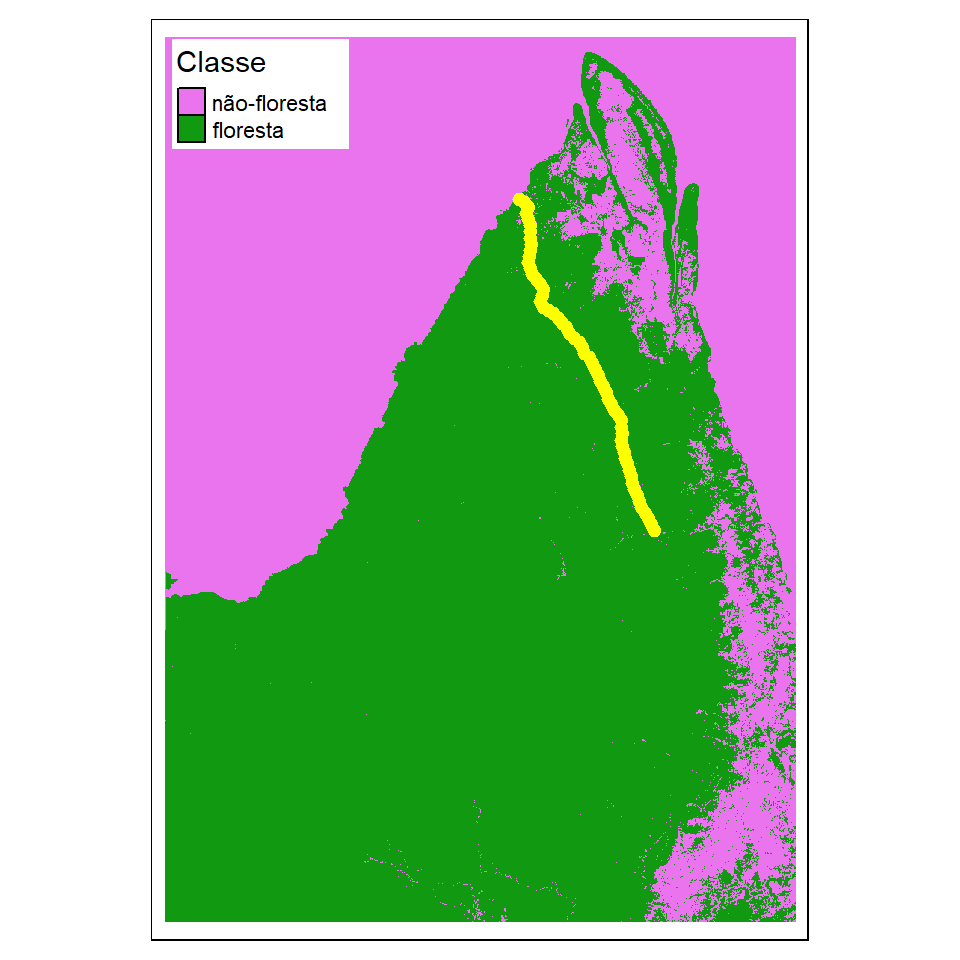

Figure 3.1: MapBiomas 2020 reclassificado em floresta e não-floresta.

# 4 Métricas da paisagem e pacote “landscapemetrics”

## 4.1 Calculo de métricas

Para ilustrar como rodar as funções e cálculos com landscapemetrics, vamos calcular a área central na paisagem que usamos no tutorial de Escala. Vamos estudar uma classe (floresta), portanto vamos incluir as métricas para nível de classe. Além disso, as métricas de paisagem em nível de classe são mais eficazes na definição de processos ecológicos (Tischendorf, L. Can landscape indices predict ecological processes consistently?. Landscape Ecology 16, 235–254 (2001). https://doi.org/10.1023/A:1011112719782.).

Métricas de área central (“core area”) são consideradas medidas da qualidade de hábitat, uma vez que indica quanto existe realmente de área efetiva de um fragmento, após descontar-se o efeito de borda. Vamos calcular a percentual de área central (“core area”). Isso seria, a percentual de áreas centrais (excluídas as bordas de 30 m) de cada classe em relação à área total da paisagem.

### 4.1.1 Região único, métrica única

Para a função sample_lsm() funcionar, precisamos informar (i) a paisagem (arquivo de raster), (ii) região de interesse (polígono), e por final (v) a métrica desejada.

```r
minha_amostra_250 <- sample_lsm(landscape = floresta_2020,
                                 y = br156_split_buffers[1, ],
                                 plot_id = data.frame(br156_split_buffers)[1, 'buff_lado_id'],
                            metric = "cpland",
                            edge_depth = 1)
```

Depois que executar (“run”), podemos olhar os dados com o codigo a seguir.

```r
minha_amostra_250
```

Os dados deve ter os valores (coluna value) da métrica (coluna metric) de cada classe (coluna class):

| layer | level | class | id | metric | value | plot_id | percentage_inside |
| --- | --- | --- | --- | --- | --- | --- | --- |
| 1 | class | 0 | NA | cpland | 65.76577 | 1_250_leste | 100.4415 |
| 1 | class | 1 | NA | cpland | 0.00000 | 1_250_leste | 100.4415 |

### 4.1.2 Regiões diferentes, distâncias variados, métrica única

Aqui estamos repetindo o processo 600 vezes, portanto pode demorar cerca de 15 minutos…

```r
# Somente distancias desejadas
br156_split_buffers %>%
  filter(buff_dist %in% c(250, 500, 1000, 2000, 4000)) -> br156_split
# Metricá para as distancias
minha_metrica <- sample_lsm(landscape = floresta_2020,
                                 y = br156_split,
                                 plot_id = data.frame(br156_split)[, 'buff_lado_id'],
                            metric = "cpland",
                            edge_depth = 1)
```

### 4.1.3 Grafico

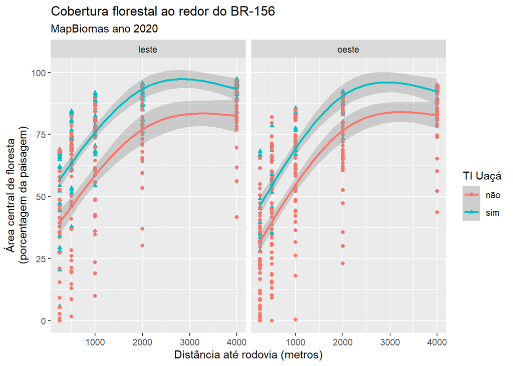

```r
# Organizar dados
resultados <- br156_split %>%
  left_join(minha_metrica %>% dplyr::select(plot_id, class, metric, value),
            by=c("buff_lado_id"="plot_id"))
# Plot
resultados %>%
  dplyr::filter(class==1) %>%
  dplyr::mutate(flag_uaca = factor(if_else(uaca_per >50, "sim", "não"))) %>%
ggplot(aes(x=buff_dist, y=value, shape = flag_uaca)) +
  geom_point(aes(colour=flag_uaca)) +
  geom_smooth(method = "gam", formula = y ~ s(x, k = 3),
              aes(colour=flag_uaca)) +
  scale_color_discrete("TI Uaçá") +
  scale_shape_discrete("TI Uaçá") +
  facet_wrap(~lado_estrada) +
  labs(title = "Cobertura florestal ao redor do BR-156",
       subtitle = "MapBiomas ano 2020",
       x = "Distância até rodovia (metros)",
       y = "Área central de floresta\n(porcentagem da paisagem)")
```

### 4.1.4 Regiões diferentes, distâncias variados, anos diferentes, métrica única

Vamos repetir o mesmo processo mais agora com 3 anos.

```r
# Somente distancias desejadas
br156_split_buffers %>%
  filter(buff_dist %in% c(250, 500, 1000, 2000, 4000)) -> br156_split
# Metricá para as distancias - 1 hora mais ou menos para rodar com 3 anos.
minha_metrica_85a20 <- sample_lsm(landscape = floresta_85a20,
                                 y = br156_split,
                                 plot_id = data.frame(br156_split)[, 'buff_lado_id'],
                            metric = "cpland",
                            edge_depth = 1)
```

E ajustando o código organizando para que os anos sejam apresentados nos gráficos. Primeiramente incluindo os atributos associados com os buffers (“br156_split”) nos resultados com as métricas (“minha_metrica_85a20”) através a função “left_join”. E depois acrescentando uma nova coluna “ano” com o ano para cada camada de paisagem (conforme a sequência de anos das rasters de MapBiomas).

```r
# Organizar dados
resultados_85a20 <- br156_split %>%
  left_join(minha_metrica_85a20 %>%
              dplyr::select(layer, plot_id, class, metric, value),
            by=c("buff_lado_id"="plot_id")) %>%
  mutate(ano = case_when(layer==1~1985,
                         layer==2~2003,
                         layer==3~2020))
```

Agora podemos fazer o grafico comparando a métrica de Área central de floresta (eixo Y) onde ha graus de proteção ambiental diferentes ao longo do BR-156 entre anos (eixo X). Para isso, apresentamos as métricas da classe de floresta (filtro - filter(class==1)), e identificando buffers com maior proteção, aqui os com mais de 50% dentro da TI Uaçá.

Para comunicar os resultados em uma forma mais clara, usamos a função “facet_grid” para apresentar os resultados em gráficos separados por lado da estrada e extensões diferentes (buffer de 250 m, 500 m, 1 km, 2 km e 4 km).

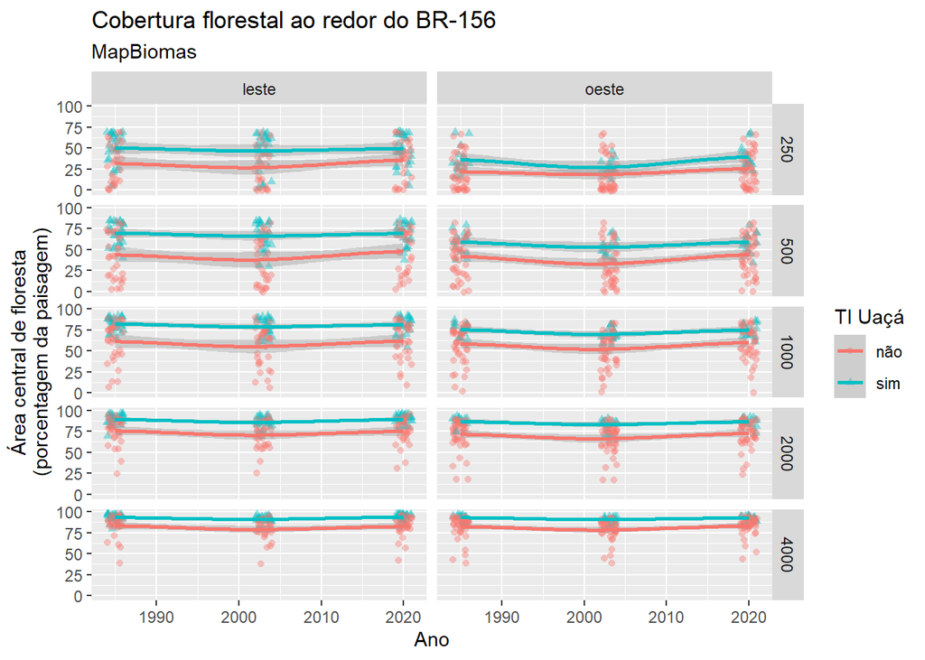

Figure 4.1: Mudanças na cobertura florestal na paisagem entre 1985 a 2020. Valores anuais de Área central (core area) de floresta, ao redor da rodovia BR-156. Porcentagem de Areá central de floresta calculados em buffers (raios de 250, 500, 1000, 2000 e 4000 metros) em torno de 60 pontos regularmente espaçados ao longo da rodovia BR-156, sul de Oiapoque. Comparando valores entre pontos com diferentes graus de proteção ambiental. Onde TI Uaça = sim são os com mais de 50% dentro da TI Uaçá, e pelo lado da estrada (lado oeste com maior cobertura da Floresta Estadual do Amapá e lado leste com maior cobertura da TI Uaçá).

```r
# floresta
resultados_85a20 %>%
  dplyr::filter(class==1) %>%
  dplyr::mutate(flag_uaca = factor(if_else(uaca_per >50, "sim", "não"))) %>%
# Plot
ggplot(aes(x=ano, y=value, shape = flag_uaca)) +
  geom_jitter(aes(colour=flag_uaca), width=1, height=1, alpha=0.4) +
  geom_smooth(aes(colour=flag_uaca)) +
  scale_color_discrete("TI Uaçá") +
  scale_shape_discrete("TI Uaçá") +
  facet_grid(buff_dist~lado_estrada) +
  labs(title = "Cobertura florestal ao redor do BR-156",
       subtitle = "MapBiomas",
       x = "Ano",
       y = "Área central de floresta\n(porcentagem da paisagem)")
```